# MATH5741M: Statistical Theory and Methods

Benjamin Thorpe

2021-08-28

Benjamin Thorpe (b.thorpe@leeds.ac.uk)  
Saturday August 28, 2021

# 6 t-tests

## 6.1 One sample t-test

Our examples in the previous chapter relied on the assumption that the variance was known. In practice, this is often not the case. If we don’t know $\sigma^2$ then we can’t define the test statistic
$$Z = \frac{\overline{X} - \mu_0}{\sqrt{\sigma^2/n}}.$$
We might consider replacing $\sigma^2$ in $Z$ with the sample variance,
$$s^{2} = \frac{1}{n-1}\sum_{i = 1}^{n}(x_{i} - \overline{x})^{2},$$
but then we are ignoring the fact that this is just a realisation of a random variable,
$$S^{2} = \frac{1}{n-1}\sum_{i = 1}^{n}(X_{i} - \overline{X})^{2},$$
which varies from sample to sample. To account for the uncertainty in both $\overline{X}$ and $S^2$, we define a new statistic
$$T = \frac{\overline{X} - \mu_0}{\sqrt{S^2/n}}.$$
If $H_0$ is true, we expect $T$ to be close to zero. If $T$ is observed to be far from zero, we have evidence against $H_0$. We might reject $H_0$ if $T$ is “far enough” from zero. But how far is “far enough”? To determine whether $T$ is improbably far from zero, we need its sampling distribution.

**Definition 6.1** Let $n$ be a positive integer. A random variable $X$ is said to follow a **t distribution with $n$ degrees of freedom** if its density function is
$$\begin{equation*}
f(x) \propto \left(1+\frac{x^2}{n}\right)^{-{(n+1)}/{2}}
\end{equation*}$$
for all $x \in \mathbb{R}$. We write $X \sim t_n$.

You are not required to memorise this density function or to integrate it. Any relevant quantities from this distribution can be obtained from R or from tables.

**Theorem 6.1** Let $X_1, \ldots, X_n$ be an IID sample from $\text{N}(\mu, \sigma^{2})$. If we think of the sample mean by $\overline{X}$ and sample variance $S^{2}$ as random variables then
$$T = \frac{(\overline{X} - \mu)}{\sqrt{S^2/n}} \sim t_{n-1}.$$
The statistic $\sqrt{S^2/n}$ on the denominator is called the **standard error** of $\overline{X}$.

Let’s devise a level $\alpha$ hypothesis test of
$$H_{0}: \mu = \mu_0 \;\;\;\text{against}\;\;\; H_{1}: \mu \neq \mu_0$$
with $T$ as our test statistic. For a level $\alpha$ test, we need a rejection region $R$ such that
$$P(T \in R) \leq \alpha$$
when $H_{0}$ is true. We know that when $H_{0}$ is true we have $\mu = \mu_0$ and therefore, by the theorem,
$$T = \frac{{\overline{X} - \mu}}{\sqrt{S^2/n}} \;\; \;\; \sim \;\; t_{n-1}\;.$$

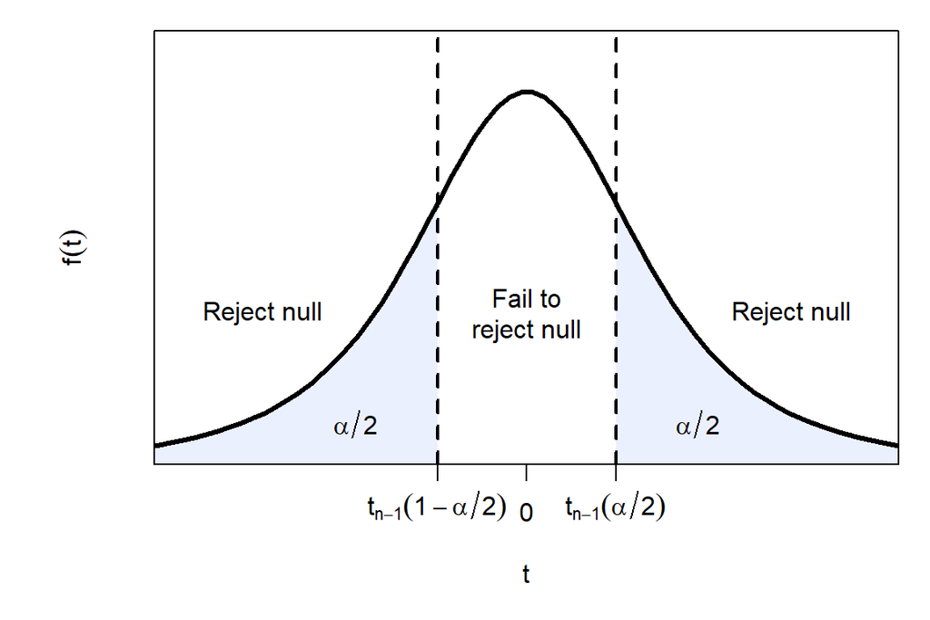

Figure 6.1: An illustration of a significance level $\alpha$ test based on the $T$ statistic. The function $f(t)$ is the density function of the distribution $t_{n-1}$. Our test rejects the null hypothesis if $T$ lies in the tails of the distribution beyond the quantiles $t_{n-1}(\alpha/2)$ or $t_{n-1}(1 - \alpha/2)$.

**Definition 6.2** For any $\gamma \in (0,1)$, the $(1 - \gamma)$ **quantile** of $T \sim t_{n-1}$ is the unique number $t_{n-1}(\gamma)$ such that $P(T \leq t_{n-1}(\gamma)) = 1 - \gamma$.

From this definition, we have
$$\begin{eqnarray*}
{\mathsf P}\Big(T \geq t_{n-1}(\alpha/2)\Big) & = & \alpha/2, \quad
{\mathsf P}\Big(T \leq t_{n-1}(1 - \alpha/2)\Big) & = & \alpha/2.\\
\end{eqnarray*}$$
The t distribution is always symmetrical about $0$, so $t_{n-1}(1 - \alpha/2) = -t_{n-1}(\alpha/2)$ and therefore
$${\mathsf P}\Big(|T| \geq t_{n-1}(\alpha/2)\Big) = \alpha.$$
So if we choose $|T| \geq t_{n-1}(\alpha/2)$ to be our criterion for rejecting $H_{0}$, then we have a level $\alpha$ test.

**Definition 6.3** The test described above is called a **t-test**.

Let’s write down a $100(1-\alpha)\%$-confidence interval. We need an interval $(U, V)$ such that
$${\mathsf P}\Big(\mu \in (U,V)\Big) \geq 1 - \alpha.$$
When $H_0:\mu = \mu_0$ is true, we know that
$${\mathsf P}\Big(|T| \geq t_{n-1}(\alpha/2) \Big) = \alpha$$
by the reasoning above, and therefore
$${\mathsf P}\Big(|T| < t_{n-1}(\alpha/2) \Big) = 1-\alpha.$$
So let’s see if we can express this as a probability for a random interval. The event $|T| < t_{n-1}(\alpha/2)$ is equivalent to
$$\begin{eqnarray*}
&& -t_{n-1}(\alpha/2) < T < t_{n-1}(\alpha/2) \\
& \Leftrightarrow & -t_{n-1}(\alpha/2) < \frac{\overline{X} - \mu}{\sqrt{S^2/n}} < t_{n-1}(\alpha/2) \\
& \Leftrightarrow & -t_{n-1}(\alpha/2)\sqrt{S^2/n} < {\overline{X} - \mu} < t_{n-1}(\alpha/2)\sqrt{S^2/n} \\
& \Leftrightarrow & -\overline{X} -t_{n-1}(\alpha/2)\sqrt{S^2/n} < \mu < -\overline{X} +t_{n-1}(\alpha/2)\sqrt{S^2/n} \\
& \Leftrightarrow & \overline{X}-t_{n-1}(\alpha/2)\sqrt{\frac{S^2}{n}} < \mu < \overline{X} + t_{n-1}(\alpha/2)\sqrt{\frac{S^2}{n}} \\
& \Leftrightarrow & \mu \in \left(\overline{X}-t_{n-1}(\alpha/2)\sqrt{\frac{S^2}{n}} \;\;,\;\; \overline{X} + t_{n-1}(\alpha/2)\sqrt{\frac{S^2}{n}}\right).
\end{eqnarray*}$$
This then implies that
$$\begin{eqnarray*}
1 - \alpha &= & {\mathsf P}\Big(|T| < t_{n-1}(\alpha/2) \Big)\\
& = & {\mathsf P}\left(\mu \in \left(\overline{X}-t_{n-1}(\alpha/2)\sqrt{\frac{S^2}{n}} \;\;,\;\; \overline{X} + t_{n-1}(\alpha/2)\sqrt{\frac{S^2}{n}}\right) \right).
\end{eqnarray*}$$

**Theorem 6.2** Let $X_{1}, \ldots, X_{n}$ be an IID sample from $N(\mu, \sigma^2)$, with both $\mu$ and $\sigma^2$ **unknown**. Then
$$\left(\overline{X}-t_{n-1}(\alpha/2)\sqrt{\frac{S^2}{n}} \;\;,\;\; \overline{X} + t_{n-1}(\alpha/2)\sqrt{\frac{S^2}{n}}\right)$$
is a $100(1-\alpha)\%$-confidence interval for $\mu$.

We can use this confidence interval to perform our level $\alpha$ t-test easily. We just observe our sample, calculate the interval, and then reject $H_0: \mu = \mu_0$ for any value of $\mu_0$ that is not inside that interval.

**Example 6.1 (heart surgery)** Consider a new method of heart surgery which (relative to other methods) improves the heart’s ability to contract. We can measure this outcome by observing a random variable $X$, the patient’s left ventricular ejection fraction (LVEF) after surgery. Suppose that

- We are happy to assume **normality**: $X \sim N(\mu, \sigma^2)$.
- $\text{var}(X) = \sigma^2$ and ${\mathsf E}(X) = \mu$ are **both unknown**.
- We will take an IID random sample of size $n = 5$.

A statistician and a surgeon both plan to analyse the same set of LVEF measurements obtained from this sample:
$$x_{1} = 70,\;\; x_{2}= 50,\;\; x_{3} = 35,\;\; x_{4} = 80,\;\; x_{5} = 40$$
The observed sample mean is
$$\overline{x} = \frac{1}{5}\sum_{i=1}^{5}x_{i} = \frac{1}{5}(70+50+35+80+40) = 55.$$
The observed sample variance is
$$\begin{eqnarray*}
s^2 & = & \frac{1}{5 - 1}\sum_{i = 1}^{5}(x_{i} - 50)^2\\ & = & \frac{1}{4}(15^2 + (-5)^2 + (-20)^2 + (25)^2 + (-15)^2) = 375
\end{eqnarray*}$$
and therefore $s^{2}/n = 375/5 = 75$.

The statistician constructs a $95\%$-confidence interval **based on the t-test**:
$$%\left(\overline{x}-t_{n-1}(\alpha/2)\sqrt{\frac{s^2}{n}} \;\;,\;\; \overline{x} + t_{n-1}(\alpha/2)\sqrt{\frac{s^2}{n}}\right) =
\left(55-t_{4}(0.025)\sqrt{75} \;\;,\;\; 55 + t_{4}(0.025)\sqrt{75}\right)$$
so he needs to determine the value of the $97.5\%$ quantile, $t_{4}(0.025)$, which is just the number such that
$$P(T \leq t_{4}(0.025)) = 97.5\%$$
for $T \sim t_{4}$. He can read this from tables or use R:

```r
qt(p = 0.975, df = 4)
```

```
## [1] 2.776445
```

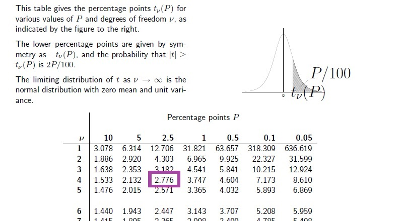

Figure 6.2: The table of t distribution quantiles provided in recent exams for this module, with the $97.5\%$ quantile highlighted.

This gives $t_{4}(0.025) \approx 2.78$. Thus, his confidence interval is
$$\left(55-2.78\sqrt{75} \;\;,\;\; 55 + 2.78\sqrt{75}\right)\approx (31, 80).$$
The surgeon instead assumes that $\sigma^2 \approx s^2 = 375$ and constructs a $95\%$-confidence interval **based on the normally distributed $Z$ test statistic**:
$$\overline{x} \pm z_{\alpha/2} \sqrt{\frac{\sigma^2}{n}} = 55 \pm z_{0.025}\sqrt{75}.$$
She needs to determine the value of the $97.5\%$ quantile for $Z \sim N(0,1)$, which can be found from tables or from R:

```r
qnorm(p = 0.975, mean = 0, sd = 1)
```

```
## [1] 1.959964
```

which gives $z_{0.025} \approx 1.96$. Thus, her interval is
$$\left(55-1.96\sqrt{75} \;\;,\;\; 55 + 1.96\sqrt{75}\right)\approx (38, 72).$$

We see from Figure 6.3 that the statistician’s results are more cautious, since his interval is wider. He would be unwilling to reject the claim that average LVEF after surgery ($\mu$) is poor (below $35$). The surgeon has a narrower interval and would reject such a claim.

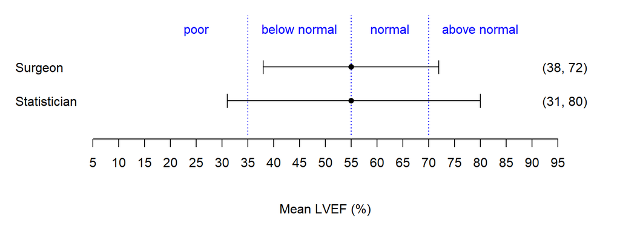

Figure 6.3: Confidence intervals obtained by the surgeon (based on the $Z$ statistic) and by the statistician (based on the $T$ statistic), along with thresholds for normal ejection fraction (blue dotted lines). Thresholds are taken from the Ejection Fraction page of the Cleveland Clinic website. This figure shows the surgeon’s interval to be less cautious, since it is narrower than the statistician’s and therefore the surgeon will reject some hypotheses that the statistician would not. For example, the statistician is unable to reject the claim that mean ejection fraction is poor.

The surgeon’s results might be pleasing to clinicians, but she is at greater risk of a Type I error if her assumption that $\sigma^2 = S^2 = 375$ is incorrect. This is because the surgeon’s narrow confidence interval rejects more potential values of $\mu$ than the statistician’s does. Therefore, if $\sigma^2 = S^2$ is in doubt, it would be safer to trust the statistician’s results.

## 6.2 Summary

So far, we have seen three ways to test the same hypothesis. All tests are based on observations from a single sample. These tests differ in their assumptions about the sample and in the distribution of the test statistic. Whenever we present a hypothesis test or confidence interval, we should always make these assumptions clear.

| $X_i$ normal | $\sigma^2$ known | $n$ large | Test statistic | Confidence limits |
| --- | --- | --- | --- | --- |
|  | Yes | Yes | $Z = \frac{\overline{X} - \mu_0}{\sqrt{\sigma^2/n}} \stackrel{\text{approx.}}{\sim} \text{N}\left(0, 1\right)$ | $\overline{X} \pm z_{\alpha/2}\sqrt{\frac{\sigma^2 }{n}}$ (approx.) |
| Yes | Yes |  | $Z = \frac{\overline{X} - \mu_0}{\sqrt{\sigma^2/n}} \sim \text{N}\left(0, 1\right)$ | $\overline{X} \pm z_{\alpha/2}\sqrt{\frac{\sigma^2 }{n}}$ |
| Yes |  |  | $T = \frac{\overline{X} - \mu_0}{\sqrt{S^2/n}}\sim t_{n-1}$ | $\overline{X} \pm t_{n-1}(\alpha/2)\sqrt{\frac{S^2 }{n}}$ |

This table lists our three options for testing $H_{0}:\mu = \mu_{0}$ vs. $H_{1}:\mu\neq\mu_{0}$. The first three columns give the assumptions required for each test. The last two columns tell us which test statistic we should use (if the assumptions are satisfied), its sampling distribution (when the null hypothesis is true) and the confidence interval that we would calculate to perform the test.

In practice, for example when writing results for a report, it is important to make sure that all of the assumptions made are clear to the reader. We can see how to check these assumptions in the practical sheets. Also, although we can use confidence intervals to perform hypothesis tests, we should present the intervals themselves, rather than just the conclusion (reject or fail to reject) of the test. We can think of a confidence interval as an interval estimate for the unknown parameter $\mu$. An interval estimate, unlike a point estimate (such as the sample mean), can communicate the uncertainty in our estimation of $\mu$.

## 6.3 Paired samples

Many experiments take the form of paired data. For example, we could measure a person’s weight before and after a specified diet. These two weights (for the same person) will usually be related (not independent). In such a situation, we might measure the effect of the treatment (the diet) by considering the difference between the two measurements, $x_{1i}$ and $x_{2i}$, for the $i$-th individual before and after treatment. Then we determine the effect of the treatment by considering the differences:
$$d_i=x_{1i}-x_{2i} \quad \text{for } i=1,\ldots,n.$$
These $d_i$ values can then be used to create a confidence interval for the effect of the treatment on the values.

This kind of analysis doesn’t just apply to pairs of measurements in the same individual. Matched pairs are often used in clinical trials, where patients are paired such that each pair shares as many common characteristics (e.g. same age, sex, weight, height) as possible. Then one individual in each pair is given treatment A, and the other treatment B.

**Example 6.2 (matched cohort study)** Consider the new method of heart surgery from our previous example. To assess its effectiveness relative to the standard method of surgery, we match each of the treated patients (the experimental group) with a patient who received the standard surgery (the control group) of the same age, gender and pre-surgery heart function. Thus we have the following data set:

| Patient pair ($i$): | 1 | 2 | 3 | 4 | 5 |
| --- | --- | --- | --- | --- | --- |
| Experimental group ($X_{1i}$): | 70 | 50 | 35 | 80 | 40 |
| Control group ($X_{2i}$): | 71 | 45 | 30 | 70 | 34 |
| Difference ($D_{i} = X_{1i} - X_{2i}$): | -1 | 5 | 5 | 10 | 6 |

Let’s assume that the **differences** are an IID random sample with
$$D_{i} \sim N(\mu, \sigma^2)$$
where $\mu$ and $\sigma^2$ now represent the population mean and variance **of the differences**. We can construct a $95\%$-confidence interval for $\mu$ based on the t test:
$$\left(\overline{d}-t_{n-1}(\alpha/2)\sqrt{\frac{s^2}{n}} \;\;,\;\; \overline{d} + t_{n-1}(\alpha/2)\sqrt{\frac{s^2}{n}}\right)$$
where $\overline{d}$ and $s^2$ are the sample mean and sample variance of the observed **differences**.
$$\overline{d} = 5 \;\;\text{and}\;\; s^2 = 15.5$$
and therefore we have a confidence interval
$$\left(5 - 2.78\sqrt{\frac{15.5}{5}} \;\;,\;\; 5 + 2.78\sqrt{\frac{15.5}{5}}\right)\approx (0.1, 9.9).$$
This interval does not contain $0$ so, at the $5\%$ significance level, we would reject the claim that there is no difference between the two treatments. The entire interval is above $0$, therefore we would also reject claims that the new surgery has a negative effect on LVEF, on average, when compared to the control treatment.

## 6.4 Independent samples

In the previous example we had two samples, but the pairing meant that we should consider paired differences as a single sample for our analysis. There are situations in which we will have two **independent** samples. Suppose that we plan to take independent random samples, of sizes $n_1$ and $n_2$ from two different populations,
$$\{X_{11}, X_{12},\ldots, X_{1\,n_1}\} \;\;\; \text{and} \;\;\; \{X_{21}, X_{22}, \ldots, X_{2\,n_2}\},$$
the first from population $1$ and the second from population $2$. Suppose that we want to estimate the average difference between the two populations:
$$\delta = \mu_1-\mu_2$$
where $\mu_j$ is the mean in population $j$ (for $j=1,2$). An obvious estimator of $\mu_1-\mu_2$ is the difference between the sample means:
$$\widehat{\delta} = \overline{X}_1 - \overline{X}_2$$
where $\overline{X}_j$ is the mean of the sample from population $j$. This gives us a point estimate for $\delta$, but how can we get a confidence interval?

In the following two theorems we will assume normality in each sample:
$$X_{1i}\sim N(\mu_1,\sigma_1^2) \quad\text{and}\quad X_{2i}\sim N(\mu_2,\sigma_2^2),$$
and we will denote by $S_1^2$ the sample variance in sample $1$ and by $S_2^2$ the sample variance in sample $2$.

**Theorem 6.3** Assume **independence both between and within** each sample. Assume **normality** in each sample and **equal variances** ($\sigma_1^2 = \sigma_2^2$). Then
$$\left(\overline{X}_1 - \overline{X}_2\right) \;\pm\; t_{n_1+n_2-2}\left(\frac{\alpha}{2}\right) S_p \sqrt{\frac{1}{n_1}+\frac{1}{n_2}}$$
gives a $100(1-\alpha)\%$-confidence interval for $\delta = \mu_{1}-\mu_{2}$, where
$$\begin{equation}
S_p^2=\frac{(n_1-1)S_1^2+(n_2-1)S_2^2}{n_1+n_2-2}\nonumber
\end{equation}$$
is the **pooled estimator** of the variance ($\sigma_{1}^2 = \sigma_2^2$).

**Theorem 6.4** Assume **independence both between and within** each sample. Assume **normality** in each sample, but **not** equal variances ($\sigma_1^2 \neq \sigma_2^2$). Then
$$\left(\overline{X}_1 - \overline{X}_2\right) \;\pm\; t_{\nu}\left(\frac{\alpha}{2}\right) \sqrt{\frac{S_1^2}{n_1}+\frac{S_2^2}{n_2}}$$
gives an approximate $100(1-\alpha)\%$-confidence interval for $\delta = \mu_{1}-\mu_{2}$, where
$$\nu=\frac{(S_1^2/n_1+S_2^2/n_2)^2}{(S_1^2/n_1)^2/(n_1-1)+(S_2^2/n_2)^2/(n_2-1)}.$$

Please don’t worry that you will need to learn the formulae for $S_p^2$ or $\nu$ here. If they are needed then they will be given. However, you should pay very careful attention to the assumptions of each theorem and how they differ.

**Example 6.3 (a randomised clinical trial)** Consider again the new method of heart surgery from our previous example. To obtain more conclusive evidence of its effectiveness, we conduct a trial on $52$ patients. We randomly allocate $n_1 = 30$ patients to the new surgery (the experimental group) and $n_2 = 22$ to the standard surgery (the control group). We measure the post-surgery LVEF of patients in each group and observe
$$\begin{eqnarray*}
\overline{x}_1 = 60,\quad \overline{x}_2 = 50,\quad s_1^2 = 400,\quad s_2^2 = 225.
\end{eqnarray*}$$
Although the **sample** variances are clearly different, we might still assume that the **population** variances are the same (a common rule of thumb is to assume the population variances are the same if the ratio of the sample standard deviations is somewhere between $1/3$ and $3$, or between $1/4$ and $4$ for small samples). So let’s assume that post-surgery LVEF observations in the experimental and control groups follow the distributions
$$N(\mu_1, \sigma^2) \quad \text{and}\quad N(\mu_{2}, \sigma^2)$$
respectively. Can we reject the claim that $\mu_1 - \mu_2 = 0$? In other words, can we reject the claim that the method of surgery has no effect on LVEF, on average? Let’s construct a $95\%$-confidence interval for $\mu_1 - \mu_2$:
$$\left(\overline{X}_1 - \overline{X}_2\right) \;\pm\; t_{n_1+n_2-2}\left(\frac{\alpha}{2}\right) S_p \sqrt{\frac{1}{n_1}+\frac{1}{n_2}}.$$
We can easily write down some of the necessary observed quantities:
$$\begin{eqnarray*}
\left(\overline{x}_1 - \overline{x}_2\right) & =& 10, \\
\sqrt{\frac{1}{n_1}+\frac{1}{n_2}} & \approx & 0.2806918,\\
t_{n_1+n_2-2}\left(\frac{\alpha}{2}\right) & = & t_{50}\left(0.025\right) \approx 2.009,
\end{eqnarray*}$$
but we also need to calculate the pooled estimate of the variance,
$$\begin{eqnarray*}
s_p^2 & = &\frac{(n_1-1)s_1^2+(n_2-1)s_2^2}{n_1+n_2-2}\\
& = & \frac{29\times 400 + 21\times 225}{50} = 326.5.\nonumber
\end{eqnarray*}$$
Putting all of this together, we get confidence limits
$$10 \pm 2.009 \times \sqrt{326.5} \times 0.2806918 \;\;\approx\;\; 10 \pm 10.2,$$
which we write as the interval $(-0.2, 20.2)$. So we **can’t** reject (at the $5\%$ level) the claim the treatment is ineffective ($\mu_1 - \mu_2 = 0$).

But what happens if we change our assumptions to
$$N(\mu_1, \sigma_1^2) \quad \text{and}\quad N(\mu_{2}, \sigma_2^2)$$
with $\sigma_1^2 \neq \sigma_2^2$? Then we need a confidence interval of the form
$$\left(\overline{X}_1 - \overline{X}_2\right) \;\pm\; t_{\nu}\left(\frac{\alpha}{2}\right) \sqrt{\frac{S_1^2}{n_1}+\frac{S_2^2}{n_2}}.$$
The difficulty here is writing down the number of degrees of freedom,
$$\begin{eqnarray*}
\nu & = & \frac{(S_1^2/n_1+S_2^2/n_2)^2}{(S_1^2/n_1)^2/(n_1-1)+(S_2^2/n_2)^2/(n_2-1)}\\
& = & \frac{(400/30 + 225/22)^2}{(400/30)^2/(29)+(225/22)^2/(21)} \approx 50.
\end{eqnarray*}$$
So our interval is
$$10 \pm 2.009 \times \sqrt{\frac{400}{30} + \frac{225}{22}} \;\;\approx\;\; 10 \pm 9.8,$$
which we can write as the interval $(0.2, 19.8)$. So we get a narrower interval. Here we **can** reject the claim that the treatment is ineffective.

How do we address these points in our research? Any assumptions should be justified, stated clearly and checked. We should always look at the confidence interval itself, not just specific hypotheses that it might reject. In this example, the interval was very wide in both cases, including values very close to zero (suggesting that the new surgery is barely effective) and values around $20$ (suggesting that the new surgery will, on average, result in heart function $20\%$ higher than the standard surgery), so an honest conclusion is that, even after our trial, there is still a lot of uncertainty in how effective the new surgery is.

## 6.5 One-sided testing

In an experiment, we often want to know if something is changed in a particular direction as a result of some intervention. For example, whether a new drug **reduces** blood pressure. This leads us to null and alternative hypotheses (respectively):

- the new drug does not reduce blood pressure (it could even increase it),
- the new drug reduces blood pressure.

The above example would require a **one-sided** test. In general, if the alternative is of the form “$\ne$”, then we need a two-sided test (including all of the examples we have seen in previous sections), whereas if it is either “$>$” or “$<$” it is one-sided.

Although we will not cover one-sided testing in depth, it is easy to adapt the testing procedures that we have already seen to deal with one-sided hypotheses. For example, when calculating the p-value for a one-sided t test, we would just take $p = {\mathsf P}(T > t)$ or $p = {\mathsf P}(T < t)$ (depending on the direction of the inequality in the alternative hypothesis) rather than calculating $p = {\mathsf P}(|T| > t)$ as in a two-sided test (in all cases, $t$ denotes the observed value of our test statistic). In R, this can be implemented in the `t.test()` function by setting `alternative = "less"` or `alternative = "greater"`.

In many situations, including clinical trials, a two-sided test is preferred. If in doubt, use a two-sided test. If you use a one-sided test, you should not choose the direction of your alternative hypothesis on the basis of any data summaries (the hypotheses should be stated in advance of observing your sample of data).